# Predictive Modeling Process

November 4th 2016

## Objective

## Overview

- Purpose: compare different regression models and observe the optimal one for our data
- Based on the data set and statistical concepts introduced in Chapter 6, **Linear Model Selection and Regularization**, from "An Introduction to Statistical Learning" (by James et al.)

## Original Data

- Data from Credit.csv and consists of many variables
  - qualitative variables: gender, student, status, and ethnicity
  - quantitative variables: balance, age, cards, education, income, limit, and rating

## Scaled Data

- standardized version of the original credit data set
- we performed mean centering and standardizing(mean zero and sd is one)
- sclaed data because glmnet(), used for 2 of our regressions, does not take factors as data
- created a train and test set using this set

## Regression Models

## Why did we look at so many models?

- Improve accuracy
- Different models are optimal for different data sets

## Ridge Regression

- shrinkage method
- run cv.glmnet, which performs a 10-fold cross validation
- outputs intercept term and standardizes the variables by default
- We used a range of values for lambda and set intercept = FALSE and standardize = FALSE because of our prescaled data
- Choose the best model based on the minimum lambda and plot this model for visualization purposes
- calculate MSE using testing set
- Perform regression on full data set

## Ridge Regression Image

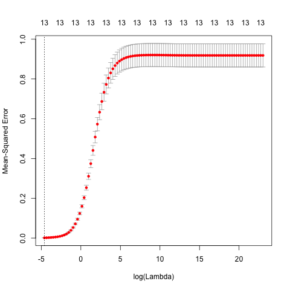

## Lasso Regression

- also a shrinkage method
- same exact process as ridge, except in cv.glmnet, set alpha = 1

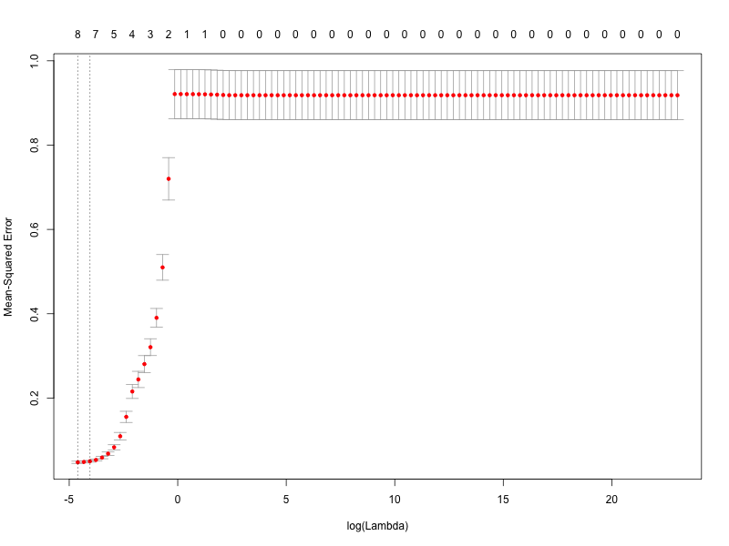

## PCR image

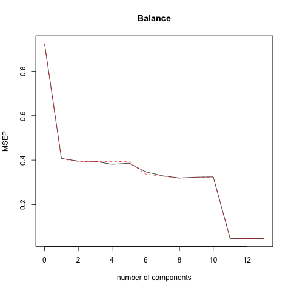

## PLSR

- another dimension reduction method
- same process as PCR, but we use plsr() isntead of pcr()

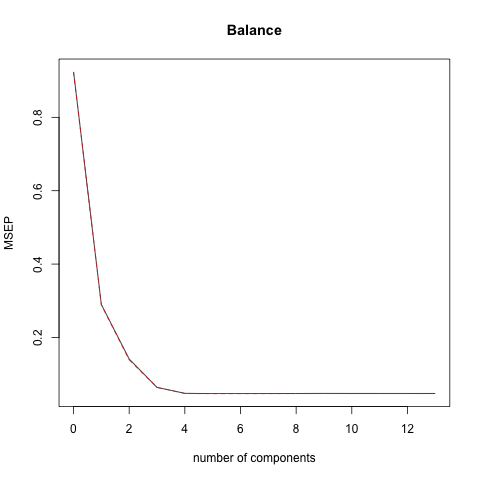

## Results

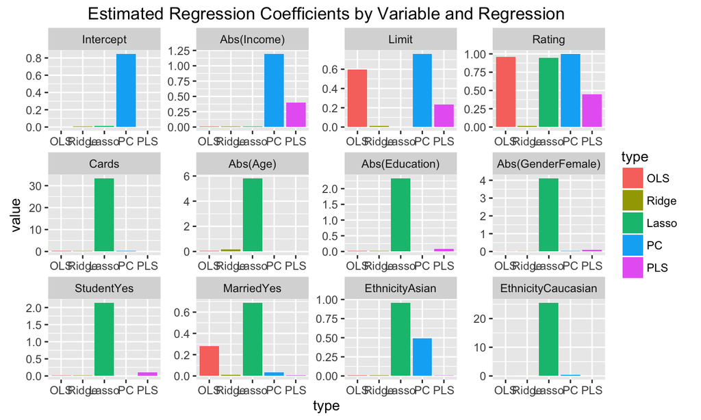

Estimated Regression Coefficients by Variable and Regression